# Explaining the Variation in the Openness of Intergovernmental Arms Control Organizations - Raw Data Appendix

Tobias Weise

This appendix tries to make the construction of the raw data-set reproducible. It lists the code that I used to create and transform the data. It also hints at other data files, e.g. from the qualitative data coding and more detailed data-sets, e.g. on the participation of NGOs or the budgets of the organizations. These files are available in the electronic data appendix.

For the analysis, I used the following R packages:[^1]

```r
library(knitr)
library(XML)
library(dplyr)
library(ineq)
library(reshape2)
library(countrycode)
library(psData)
library(ggplot2)
library(RCurl)
library(RJSONIO)
library(pander)
library(xtable)
library(lubridate)
library(tm)
```

# Dependent Variables

First, I collected a number of dependent variables on transparency and participation in intergovernmental organizations. Below, I will document how I created the individual variables and how I collected and transformed the data. In most cases, the same steps are necessary to create the data for both IAEA and OPCW. If this is not the case, I document the different procedures.

## TALK-Participation

### IAEA

- References to norm of participation in the Annual Report
- Source: number of statements in the Annual Report that refer to the idea of participation, inclusion and representation of non-state actors like NGOs, business groups or experts.
- Data derived from qualitative coding. See the IAEA RQDA file and the instructions to export the TALK-Participation codes.

```r
#create empty data-set
data <- data.frame(IO=c(rep("IAEA", 55), rep("OPCW", 15)),
                            Year = c(1957:2011, 1997:2011),
                                     Decade = c(
                                        rep("1950s", 4),
                                        rep("1960s", 10),
                                        rep("1970s", 10),
                                        rep("1980s", 10),
                                        rep("1990s", 10),
                                        rep("2000s", 10), "2010s",
                                        rep("1990s", 4),
                                        rep("2000s", 10),
                                                "2010s"))

# import codings from RQDA file
## this is commented here, as it breaks the knitr chain
#library(RQDA)
#RQDA::openProject("../data/IAEA.rqda")
#iaea_codings <- RQDA::getCodingTable()
#iaea_summary <- iaea_codings %>% group_by(filename, codename)  %>% summarise(n = n())
#save(iaea_summary, file = "iaea_summary")
load("../data/iaea_summary")

# filter for relevant codings and add to dataset
iaea_part <- as.data.frame(filter(iaea_summary,
                                codename == "TALK-Participation"))$n

# replace "missings" with 0 because they are true zeros
data$TALK.Part <- rep(NA, 70)
data$TALK.Part[which(data$IO == "IAEA")] <-
    c(iaea_part[1:5], rep(0, 2),
        iaea_part[6], rep(0, 4),
        iaea_part[7], rep(0, 16),
        iaea_part[8:9], rep(0, 2),
        iaea_part[10], rep(0,2),
        iaea_part[11:14], 0,
        iaea_part[15:28])
```

### OPCW

```r
# import my codings data from RQDA
#RQDA::openProject("../data/OPCW.rqda")
#codings <- RQDA::getCodingTable()
#opcw_summary <- codings %>% group_by(filename, codename) %>% summarise(n = n())
#save(opcw_summary, file = "opcw_summary")
load("../data/opcw_summary")

# filter for relevant codings and add to dataset
opcw_part <- as.data.frame(filter(opcw_summary,
                                codename == "TALK-Participation"))$n

# replace "missings" with 0 because they are true zeros
data$TALK.Part[which(data$IO == "OPCW")] <-
    c(0, opcw_part[1:7], 0,
    opcw_part[8:13])
```

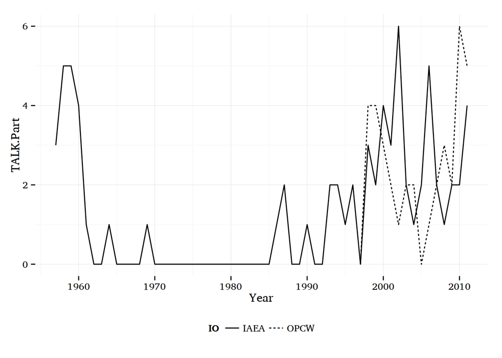

## TALK-Transparency

### IAEA

- References to norm of transparency in the Annual Report
- Source: number of statements in the Annual Report that refer directly to the principle of transparency.
- see IAEA RQDA file and instructions to get TALK-Transparency codings.

```r
# filter for relevant codings and add to dataset
iaea_trans <- as.data.frame(filter(iaea_summary,
                                codename == "TALK-Transparency"))$n

data$TALK.Trans <- rep(NA, 70)
data$TALK.Trans[which(data$IO == "IAEA")] <-
    c(rep(0, 36), iaea_trans[1], 0,
        iaea_trans[2], 0, iaea_trans[3:4], 0,
        iaea_trans[5:11], 0, iaea_trans[12:13], 0,
        iaea_trans[14])
```

### OPCW

```r
# filter for relevant codings and add to dataset
opcw_trans <- as.data.frame(filter(opcw_summary,
                                codename == "TALK-Transparency"))$n

data$TALK.Trans[which(data$IO == "OPCW")] <-
    c(0, opcw_trans[1:6], 0, opcw_trans[7],
        0, opcw_trans[8:12])
```

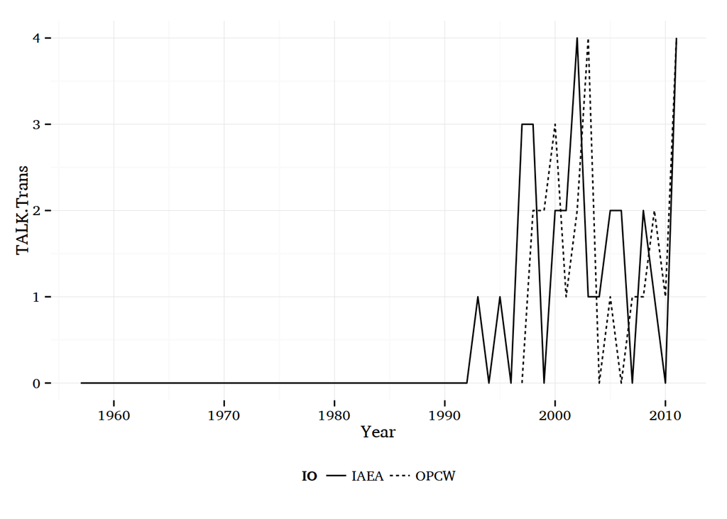

## DECISION-Participation

### IAEA

- Decisions that increase participation
- Source: General Conference resolutions, secondary literature
- 2 Levels:
  - 1: 1957-1974: fixed rules for consultation and participation in GC, yet, not really enacted after 1959
  - 2: 1975-2011: keeping the rules, yet allowing ad-hoc invitations to participate at GC without formal consultative status by GOV.

```r
data$DEC.Part <- rep(NA, 70)
data$DEC.Part[which(data$IO == "IAEA")] <-
    c(rep(1, 18), rep(2, 37))
```

### OPCW

- 3 levels:
  - 1997-1999: ad-hoc rules for passive participation
  - 2000-2002: plus access to official CSP documents
  - 2003-2011: plus limited rights to address meetings

```r
data$DEC.Part[which(data$IO == "OPCW")] <-
    c(rep(1, 3), rep(2, 3), rep(3, 9))
```

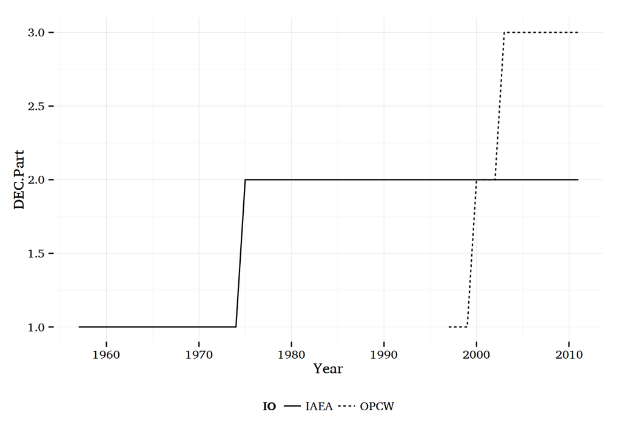

## DECISION-Transparency

### IAEA

- Decisions that increase transparency
- Source: Annual Report, General Conference resolutions and GOV decisions
- From the AR research, I propose the following 12 phases of transparency relevant decisions.
  - 1: base-line policy: mainly reactive outreach to media, partially during phases of little public demand for IAEA transparency
  - 2: issuing IAEA newsbriefs
  - 3: IAEA Highlights publication
  - 4: new PR policy: e.g. with media seminars
  - 5: Launch of IAEA website
  - 6: distribution of electronic official documents through website to public
  - 7: partial de-classification of GOV documents
  - 8: new PR strategy: outreach to non-traditional actors
  - 9: new TC policy: increase transparency
  - 10: new PR strategy: pro-active and distribution of Agency publications for free
  - 11: New PR strategy: increase outreach to devlopment community
  - 12: Using social media

```r
data$DEC.Trans <- rep(NA, 70)
data$DEC.Trans[which(data$IO == "IAEA")] <-
    c(rep(1, 29), rep(2, 3), 3, rep(4, 3),
        5, 5, 6, 7, 7, 8, 8, 9, 9, rep(10, 5),
        11, 11, 11, 12, 12)
```

### OPCW

- There are the following levels of increased transparency decisions, taken from the Annual Reports and CoSP-Resolutions
  - 1: 1997: starting level, with website and publications, yet targeted primarily towards the Member States
  - 2: 1998: increasing publications output, aiming at broader audiences and starting library
  - 3: 1999: re-worked website policy: now also targeted at general public
  - 4: 2000: Expansion of Website. “Synthesis” Journal available online for free, course material for national authorities available online
  - 5: 2002: new publications targeted at general public: OPCW Profiles, “Basic Facts” re-issue, Flyers on Basic Information
  - 6: 2003: outreach strategy aiming at broader geographical reach, launch of new publications: “OPCW Regional Series”, “Chemical Disarmament Quarterly”
  - 7: 2008: participation in “Open Day”, i.e. opening its doors to the public for 1 day, increased outreach to research institutions, website with more official documents
  - 8: 2010: starting social media activities, development of a new “Public Diplomacy Strategy” and Task Force, first steps of live reporting of OPCW events.

```r
data$DEC.Trans[which(data$IO == "OPCW")] <-
    c(1, 2, 3, 4, 4, 5, rep(6, 5), 7, 7, 8, 8)
```

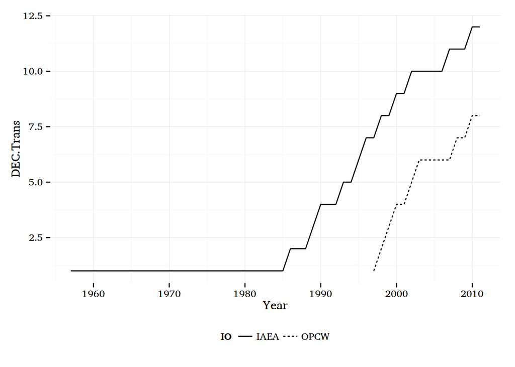

## ACTION-Participation-GC-NGO-present

### IAEA

- Number of NGOs present at annual General Conference.
- Source: Number of Non-Governmental Organizations in official list of delegations

```r
# importing my data-set on IAEA GC participation
iaea_gc_ngo <- read.csv('../data/IAEA-GC-NGOs.csv')

data$ACT.Part.1 <- rep(NA, 70)
data$ACT.Part.1[which(data$IO == "IAEA")] <-
    iaea_gc_ngo$NGO.present
```

### OPCW

- Number of NGOs present at the annual Session of the Conference of State Parties
- Source: Lists of CSP Participants (from OPCW Documents Office)

```r
# importing my data on OPCW participation
opcw_ngo <- read.csv2('../data/OPCW-CSP-NGO.csv')
data$ACT.Part.1[which(data$IO == "OPCW")] <-
    opcw_ngo$SUM.NGOS[1:15]
```

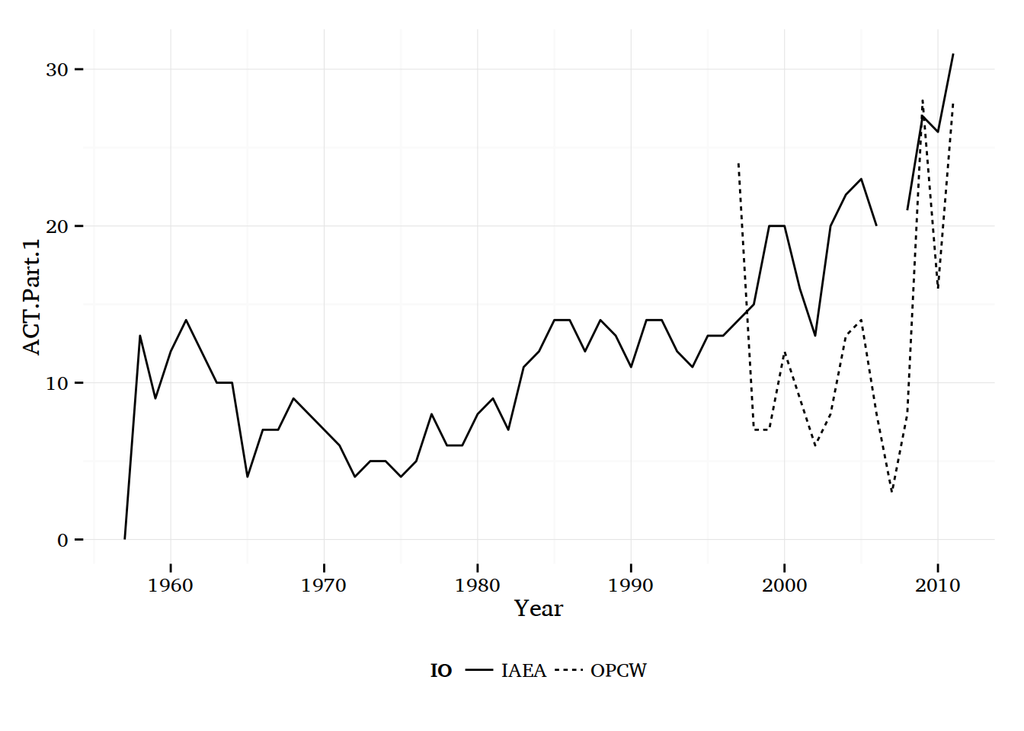

## ACTION-Participation-GC-NGO-Representatives

### IAEA

- Number of NGO representatives at General Conference
- Source: Count of registered representatives of Non-Governmental Organizations in official list of Delegations

```r
data$ACT.Part.2 <- rep(NA, 70)
data$ACT.Part.2[which(data$IO == "IAEA")] <-
    iaea_gc_ngo$Representatives.present
```

### OPCW

- Source: List of participants

```r
data$ACT.Part.2[which(data$IO == "OPCW")] <-
  opcw_ngo$SUM.NGO.REP[1:15]
```

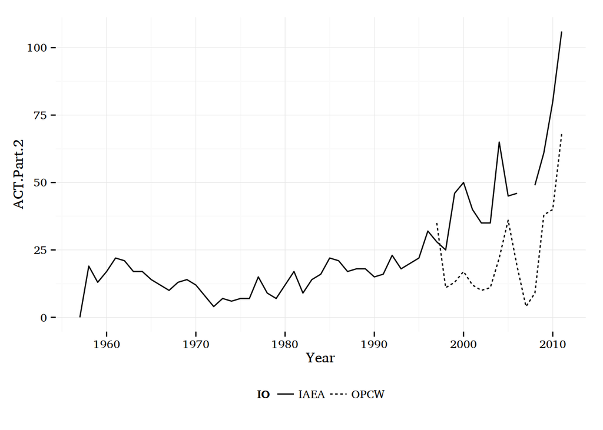

## ACTION-Participation-GC-New-NGO

### IAEA

- Number of NGOs that participate at GC for the first time
- Source: List of Non-Governmental Organizations in official list of Delegations

```r
data$ACT.Part.3 <- rep(NA, 70)
data$ACT.Part.3[which(data$IO == "IAEA")] <-
    iaea_gc_ngo$Number.of.New.NGO.present
```

How do the different IAEA measures for ACTION-Participation correlate?

```r
data %>% filter(IO == "IAEA") %>%
    select(ACT.Part.1, ACT.Part.2, ACT.Part.3) %>%
    cor(use = 'pairwise.complete.obs')
```

```
##            ACT.Part.1 ACT.Part.2 ACT.Part.3
## ACT.Part.1  1.0000000  0.9262616  0.4352693
## ACT.Part.2  0.9262616  1.0000000  0.3584847
## ACT.Part.3  0.4352693  0.3584847  1.0000000
```

So, the amount of NGOs and NGO representatives correlates highly. The presence of new NGOs, however, seems to follow a different trend.

### OPCW

```r
data$ACT.Part.3[which(data$IO == "OPCW")] <-
  opcw_ngo$NEW.NGOS[1:15]
```

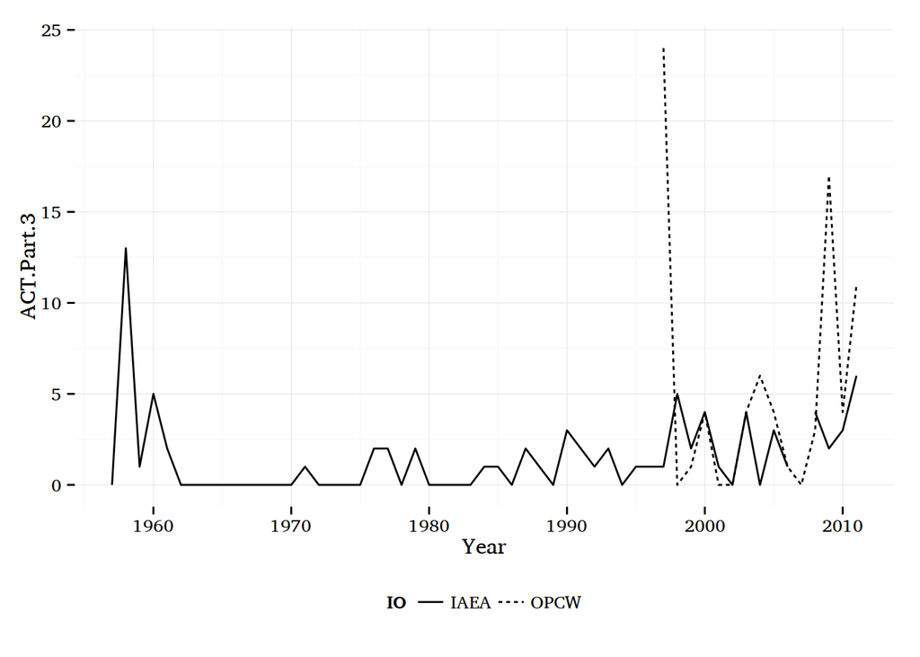

How do the different OPCW measures for ACTION-Participation correlate?

```r
data %>% filter(IO == "OPCW") %>%
  select(ACT.Part.1, ACT.Part.2, ACT.Part.3) %>%
    cor(use = 'pairwise.complete.obs')
```

```
##            ACT.Part.1 ACT.Part.2 ACT.Part.3
## ACT.Part.1   1.000000  0.8888580  0.8606050
## ACT.Part.2   0.888858  1.0000000  0.6098843
## ACT.Part.3   0.860605  0.6098843  1.0000000
```

All measures of NGOs and NGO representatives correlate highly. The presence of new NGOs, however, at the IAEA, seems to follow a different trend. I will thus use the number of NGOs and NGO representatives for the analysis.

## ACTION-Participation-Events

### IAEA

- number of participation events (i.e. events with non-state or sub-state level participation) that are discussed in the Annual Reports. Counts both actual events and more general references to events.
- Source: Annual Report, qualitative codings, guided by the following search terms:

  ```
   -  workshop
   -  training
   -  event
   -  seminar
   -  group
   -  meeting
   -  course
   -  forum
   -  exercise
   -  advisory
   -  panel
   -  symposia
   -  consultant
   -  network
  ```

```r
# filter for relevant codings and add to dataset
data$ACT.Part.4 <- rep(NA, 70)
data$ACT.Part.4[which(data$IO == "IAEA")] <-
    as.data.frame(filter(iaea_summary, codename == "ACT.Part"))$n
```

### OPCW

- number of participation events (i.e. events with non-state or sub-state level participation) that are discussed in the Annual Reports. Counts both actual events and more general references to events.
- Source: Annual Report, qualitative codings, guided by the following search terms:

  ```
  -  workshop
  -  training
  -  event
  -  seminar
  -  group
  -  course
  -  meeting
  -  forum
  -  exercise
  -  Board
  -  advisory
  -  project
  -  committee
  -  program
  ```

```r
# filter for relevant codings and add to dataset
data$ACT.Part.4[which(data$IO == "OPCW")] <-
    as.data.frame(filter(opcw_summary, codename == "ACT.Part"))$n[2:16]
```

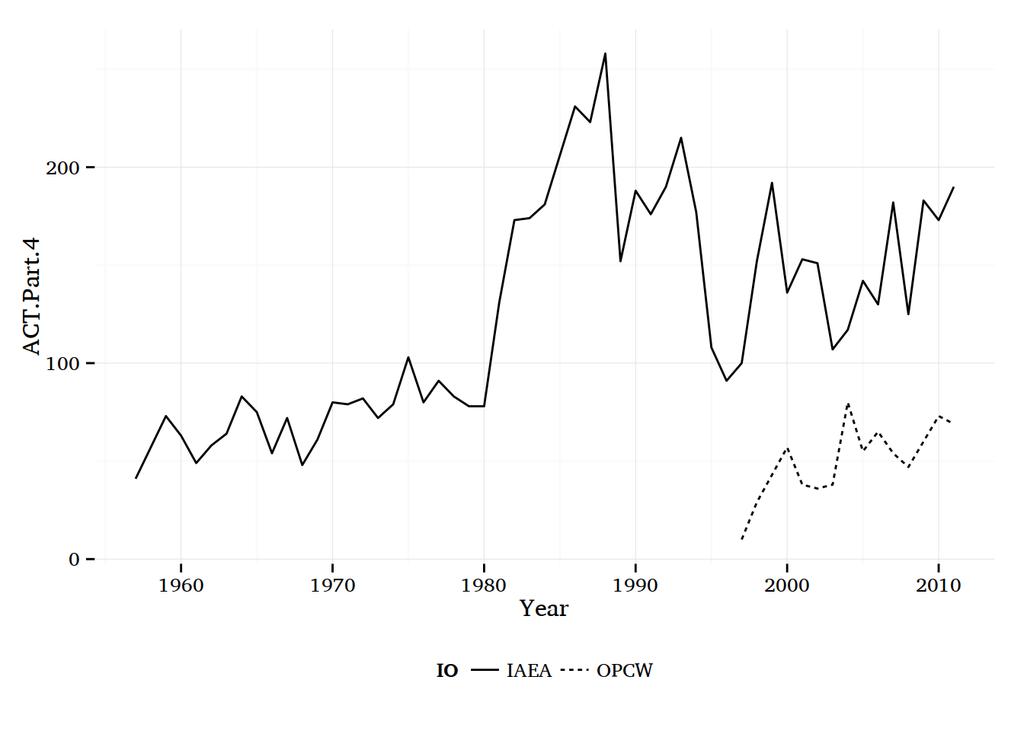

How do the two participation action data correlate?

```r
cor(data$ACT.Part.1, data$ACT.Part.4, use = "pairwise.complete.obs")
```

```
## [1] 0.3526807
```

There is only weak correlation, so it matters which of the indicators are chosen as they measure different aspects of participation. I will thus include both in my analysis.

## ACTION-Transparency-Public Information Budget

### IAEA

- share of the Budget available for public information
- source: annual budget reports (often under Administrative Department, or listed under “distribution of information”)
- From 1957 to 1970: costs for distribution of information, 1971-1972: separate division of information, 1973-1979: public information part of office of external relations, budget shows that part of public information on former external relations budget is about 45 percent. I therefore use 45 percent of the 1973-1979 budget for the data row, 1980: separate division of public information, since 2002: under Information support services. Also, additional budget for ICT, I added this to the usual public information costs, as websites etc. provide transparency.
- also see see RB-BudgSize

```r
# importing my data-set on IAEA budgets
iaea_budget <- read.csv2('../data/IAEA-BUDGET.csv')
data$ACT.Trans.1 <- rep(NA, 70)
data$ACT.Trans.1[which(data$IO == "IAEA")] <-
    iaea_budget$Public.Information.Budget / iaea_budget$Total.Budget
```

### OPCW

- The share of the total budget that the OPCW spends for external relations and information systems
- Source: OPCW budgets. Total budgeted expenditures for the *External Relations* and *Information Systems* programs.

```r
# importing my data-set on OPCW budgets
opcw_budget <- read.csv2('../data/OPCW-BUDGET.csv', dec = '.')
data$ACT.Trans.1[which(data$IO == "OPCW")] <-
    opcw_budget$Public.Information.Budget[1:15] /
    opcw_budget$Total.Budget[1:15]
```

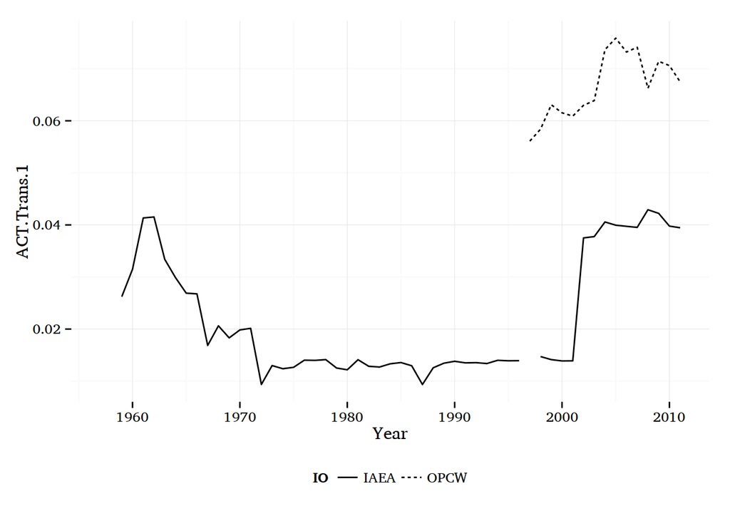

# Independent Variables

Next, here is the description of the construction of the independent variables. `RB` identifies resource-based mechanisms, `NB` the norm-based ones.

## RB-BudgSize

### IAEA

- Annual Budget in 2009 USD
- In years where there were 2 year budgets, I take the data from the updated budgets for each year, if available.
- If available, I give preference to the “Total Operational Regular Budget” (by item of expenditure, total costs) numbers, when available, because this lists staff costs.
- When there are price estimates, I always use the prize estimates for the budgeted year.
- Source: annual budget reports. Note: budgets for year x is discussed and presented in GC x-1
- Source for conversion in 2009 USD: GDP Deflator data, US DoC, BEA, Table 1.1.9
- Source for conversion rates EUR, USD for 2006 - 2012: ECB, statistics data warehouse, averaged standardized measures

```r
# fetch conversion rates from EUR to USD because IAEA changed
# accounting to EUR in 2006
url <- "http://sdw.ecb.europa.eu/browseTable.do?DATASET=0&node=2018794&FREQ=A&CURRENCY=USD&sfl1=4&sfl3=4&SERIES_KEY=120.EXR.A.USD.EUR.SP00.A"

table <- htmlParse(getURL(url))
table <- readHTMLTable(table)
EUR_USD <- as.data.frame(table[5])
EUR_USD <- arrange(EUR_USD, NULL.V1)
iaea_budget$exchange <- c(rep(1, 49),
        as.numeric(as.character(EUR_USD$NULL.V2[10:15])))

# for conversion to 2009 USD, use GDP deflator, source cannot be
# loaded with R
#url2 <- "http://www.bea.gov/iTable/iTableHtml.cfm?reqid=9&step=3&
#isuri=1&910=x&911=0&903=13&904=1957&905=2011&906=a"
iaea_budget$deflator <- c(16.641,   17.018, 17.254, 17.493, 17.686,
        17.903, 18.105, 18.383, 18.720, 19.246, 19.805, 20.647, 21.663,
        22.805, 23.964, 25.005, 26.366, 28.734, 31.395, 33.119, 35.173,
        37.643, 40.750, 44.425, 48.572, 51.586, 53.623, 55.525, 57.302,
        58.458, 59.949, 62.048, 64.460, 66.845, 69.069, 70.644, 72.325,
        73.865, 75.406, 76.783, 78.096, 78.944, 80.071, 81.891, 83.766,
        85.054, 86.754, 89.132, 91.991, 94.818, 97.335, 99.236, 100.000,
        101.211, 103.199)

# now, calculate IAEA budget in 2009 USD
data$RB.Budget.All <- rep(NA, 70)
data$RB.Budget.All[which(data$IO == "IAEA")]  <-
    iaea_budget$exchange * iaea_budget$Total.Budget *
    (100 / iaea_budget$deflator)
```

### OPCW

- Total Budget of OPCW in 2009 USD
- Source: Annual Budget Decisions from CoSP

```r
# Need EUR to USD conversion rates and NLG to USD rates for 1997-1999
## NLG to USD rates from Netherlands National Bank, make R recognize
## ',' as decimal point
url5 <- "http://www.statistics.dnb.nl/index.jsp?lang=nl&todo=Koersen&service=show&data=21&type=y&cur=g&s=1&begin1=1997&end1=1999"
table <- htmlParse(getURL(url5))
table <- readHTMLTable(table)
NLG_USD <- as.data.frame(table[2])
write.csv(NLG_USD[c(1,3)], file = 'nlg_usd.csv')
NLG_USD <- read.csv('nlg_usd.csv', dec = ",")

opcw_budget$exchange <- c(1 / NLG_USD$NULL.1[1:3],
        as.numeric(as.character(EUR_USD$NULL.V2[4:17])))

# as above, convert to 2009 USD, using GDP deflator and add to data-set
opcw_budget$deflator <- c(iaea_budget$deflator[41:55],
        105.002,    106.590)
data$RB.Budget.All[which(data$IO == "OPCW")]  <-
    opcw_budget$exchange[1:15] *
    opcw_budget$Total.Budget[1:15] * (100 / opcw_budget$deflator[1:15])
```

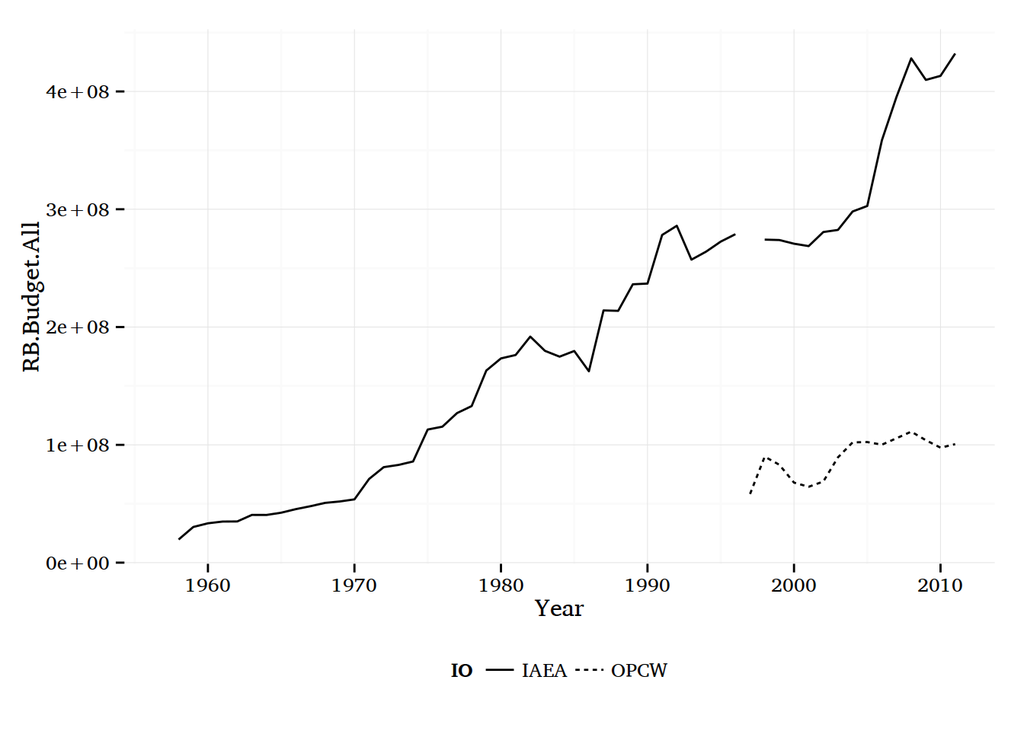

## RB-StaffCosts

### IAEA

- staff costs as share of total operational budget
- staff costs taken from budget reports, including salaries and general staff costs
- Source: budget reports, see RB-BudSize.

```r
data$RB.Budget.Staff <- rep(NA, 70)
data$RB.Budget.Staff[which(data$IO == "IAEA")] <-
    iaea_budget$Staff.Costs / iaea_budget$Total.Budget
```

### OPCW

- Staff costs (including salaries and general staff costs) as a share of the total budget.
- Source: OPCW budgets.

```r
data$RB.Budget.Staff[which(data$IO == "OPCW")] <-
    opcw_budget$Staff.Costs[1:15] /
    opcw_budget$Total.Budget[1:15]
```

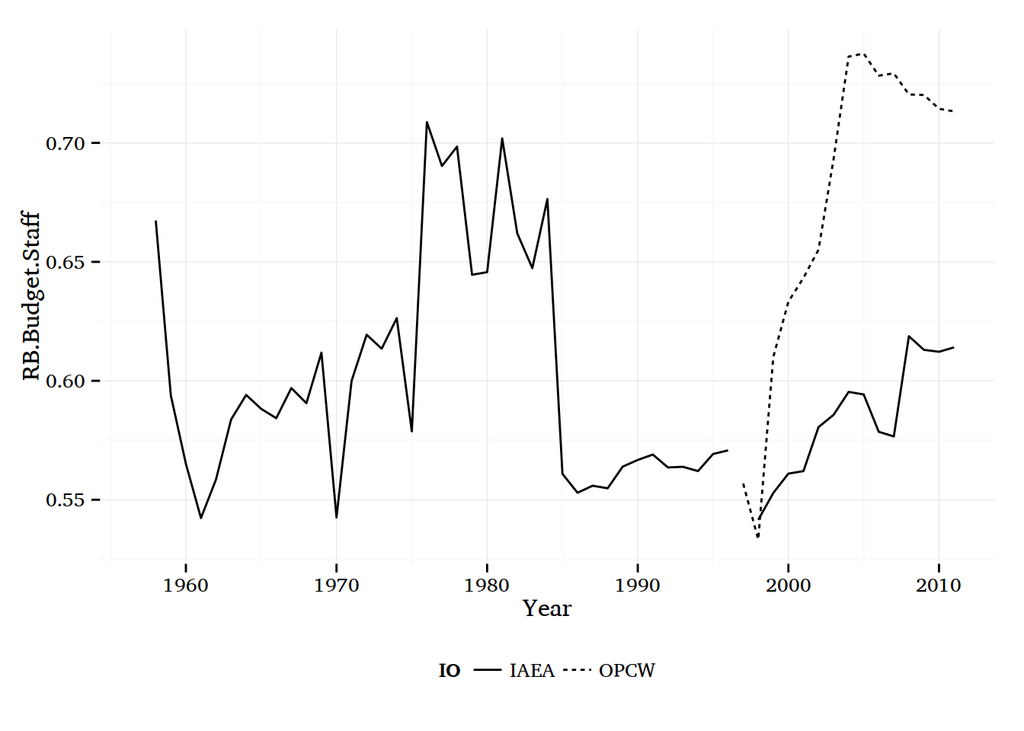

How do the two budget measures correlate?

```r
cor(data$RB.Budget.All, data$RB.Budget.Staff,
        use = 'pairwise.complete.obs')
```

```
## [1] -0.2554299
```

There is weak negative correlation, so they rather measure different things.

## RB-IneqMembers

### IAEA

- Measures the inequality of the member states. I use the Gini Coefficient of the annual GDP data for the members. The higher the coefficient, the more inequal the states are.
- Membership Data taken from the IAEA Website
- source: Penn World Tables 8.0, Real GDP at constant 2005 national prices (in mil. 2005US$) for states that are available.
- Limited data resources limit the interpretation of the results. Calculated inequality will probably be smaller than actual one.

```r
# I take the IAEA membership data from the Agency's website.
# For reasons of reproducibility, I take an archived version
url_iaea = "https://web.archive.org/web/20140125141116/http://www.iaea.org/About/Policy/MemberStates/"

table <- htmlParse(getURL(url_iaea))
table <- readHTMLList(table)

table_iaea <- table[[6]]
table_iaea <-   data.frame(matrix(unlist(table_iaea), nrow=45, byrow=T))
colnames(table_iaea) <- "data"
table_iaea$data <- as.character(table_iaea$data)
# add empty cell for 2010 and add missing years
table_iaea[41,] <- "2010: none"
table_iaea[46,] <- "1971: none"
table_iaea[47,] <- "1975: none"
table_iaea[48,] <- "1978: none"
table_iaea[49,] <- "1979: none"
table_iaea[50,] <- "1980: none"
table_iaea[51,] <- "1981: none"
table_iaea[52,] <- "1982: none"
table_iaea[53,] <- "1985: none"
table_iaea[54,] <- "1987: none"
table_iaea[55,] <- "1988: none"
table_iaea[56,] <- "1989: none"
table_iaea[57,] <- "1990: none"
table_iaea[58,] <- "1991: none"

# tidy the data
table_iaea <- colsplit(table_iaea$data, ": ", c("year", "countries"))
table_iaea <- arrange(table_iaea, year)
countries_iaea <- list()
for (i in seq(along = table_iaea$year)) {
countries_iaea[i] <- strsplit(as.list(table_iaea$countries)[[i]], ", ")
  }

countries_iaea <- melt(countries_iaea)
countries_iaea$Year <- countries_iaea$L1 + 1956
countries_iaea$L1 <- NULL
countries_iaea <- filter(countries_iaea, Year < 2012)
countries_iaea <- filter(countries_iaea, value != "none")

write.csv(countries_iaea, file="iaea_members.csv")

# convert table into country-year format
# see for reference:
# http://stackoverflow.com/questions/5425584/creating-new-
#variable-and-new-data-rows-for-country-conflict-year-observations
countries_iaea$end.date <- rep(2011, length(countries_iaea$Year))

library(plyr)
members_iaea <- ddply(countries_iaea, .(value), function(x){
    data.frame(
        #country=x$Member.State,
        Year=seq(x$Year, x$end.date)
        #accession=x$accession
        #yrend=x$end
    )
}
)
detach("package:plyr", unload=TRUE)

# join gdp and membership data
# first, add country code to cow data with countrycodes-package
members_iaea$isoc <-
    countrycode(members_iaea$value,
                              origin="country.name",
                              destination="iso3c", warn=T)


# get Penn World Tables data for all states, Real GDP at constant
# 2005 national prices, downloaded as csv from url below
# url2 <- "http://citaotest01.housing.rug.nl/FebPwt/Dmn/AggregateXs.mvc/
# PivotShow#"
penn_gdp <- read.csv('../data/PENN-GDP.csv')

# join / merge
iaea_ineq <- merge(x = members_iaea, y = penn_gdp,
                                     by.x = c("isoc", "Year"),
                                     by.y = c("RegionCode", "YearCode"))

# those stats are not in the merged data set
# because GDP data is missing
setdiff(unique(members_iaea$isoc), unique(iaea_ineq$isoc))
```

```
##  [1] "AFG" "CUB" "HTI" "VAT" "MCO" "MMR" "YUG" "DZA" "LBY" "LIE" "ARE"
## [12] "NIC" "MHL" "ERI" "SYC" "PLW" "TON"
```

```r
# calculate Gini per year
iaea_ineq2 <- iaea_ineq %>% group_by(Year) %>%
    summarise(members = n(), gini = ineq(AggValue),
                        mean = mean(AggValue))

data$RB.Inequality <- rep(NA, 70)
data$RB.Inequality[which(data$IO == "IAEA")] <-
    iaea_ineq2$gini
```

### OPCW

```r
# I take data from membership table off OPCW website
url_opcw = "https://web.archive.org/web/20140108120526/http://www.opcw.org/about-opcw/member-states/"


table <- htmlParse(getURL(url_opcw))
table <- readHTMLTable(table)

table_opcw <- as.data.frame(table[[4]])
table_opcw$accession <- year(dmy(table_opcw$"Entry into Force"))
table_opcw$Member.State <- as.character(table_opcw$"Member State")

table_opcw <-
    table_opcw %>% select(accession, Member.State) %>% arrange(accession)

write.csv(table_opcw, file="opcw_members.csv")

# convert table into country-year format
# see for reference:
# http://stackoverflow.com/questions/5425584/creating-new-variable-and-new-
#   data-rows-for-country-conflict-year-observations
table_opcw$end.date <- rep(2011, length(table_opcw$accession))

library(plyr)
members_opcw <- ddply(table_opcw, .(Member.State), function(x){
    data.frame(
        #country=x$Member.State,
        Year=seq(x$accession, x$end.date)
        #accession=x$accession
        #yrend=x$end
        )
    }
)
detach("package:plyr", unload=TRUE)

# join gdp and membership data
# first, add country code to cow data with countrycodes-package
members_opcw$isoc <-  countrycode(members_opcw$Member.State,
        origin="country.name", destination="iso3c", warn=T)


# join / merge
opcw_ineq <- merge(x = members_opcw, y = penn_gdp,
        by.x = c("isoc", "Year"), by.y = c("RegionCode", "YearCode"))

#write.csv2(opcw_ineq, file = "opcw_members_gdp")

# those states are not in the merged data set
# because GDP data is missing
setdiff(unique(members_opcw$isoc), unique(opcw_ineq$isoc))
```

```
##  [1] "AFG" "DZA" "AND" "COK" "CUB" "ERI" "GUY" "HTI" "VAT" "KIR" "LBY"
## [12] "LIE" "MHL" "FSM" "MCO" "NRU" "NIC" "NIU" "PLW" "PNG" "WSM" "SMR"
## [23] "SYC" "SLB" "SOM" "TLS" "TON" "TUV" "ARE" "VUT"
```

```r
# calculate Gini per year
opcw_ineq2 <- opcw_ineq %>% group_by(Year) %>%
    summarise(members = n(), gini = ineq(AggValue),
    mean = mean(AggValue))


data$RB.Inequality[which(data$IO == "OPCW")] <-
    opcw_ineq2$gini
```

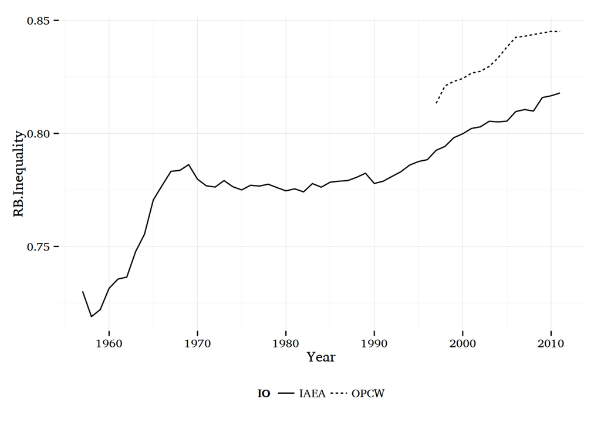

## RB-Complexity

### IAEA

- Measures the complexity of the policy field that the organization covers.
- I create a qualitative variable. I quantify the number of activities that the organizations’ statutes say the organizations have. I assume that the more tasks the organization has to fulfill, the more complex its operations are.
- The IAEA statute (Art III) lists the following tasks
  1. encourage, assist and conduct research, develop practical applications foster scientific exchange
  2. act as intermediary for supply of materials, services, or facilities for states
  3. provide nuclear materials, services, equipment and facilities with focus on developing states, i.e. technical assistance
  4. establish and administer safeguards
  5. develop and apply safety standards

```r
data$RB.Complexity <- rep(NA, 70)
data$RB.Complexity[which(data$IO == "IAEA")] <-
    c(rep(5, 55))
```

### OPCW

- The CWC, which is also the founding document of the OPCW, lists the following tasks for the OPCW:
  1. implementation and verification of chemical weapons destruction (Art. VIII)
  2. assistance and protection against chemical weapons (Art X)
  3. economic and technical development (Art XI)

```r
data$RB.Complexity[which(data$IO == "OPCW")] <-
    c(rep(3, 15))
```

## NB-Press Salience

### IAEA

- Shows how visible the organization is in the global press.
- source: hits in the “major world news” corpus of Lexis Nexis

First, I show that there are no effects of the larger corpus size and that the reporting of total numbers is a good indicator for visibility.

```r
# import my IAEA Lexis-Nexis data
iaea_media <- read.csv2("../data/IAEA-MEDIA.csv")
cor(iaea_media$All.Hits, iaea_media$All.WashPost,
        use = 'pairwise.complete.obs')
```

```
## [1] 0.9360839
```

There is high correlation (0.936) between `All Media Hits` and those in the `Washington Post` only. Thus, the higher number of sources in the corpus in later years does not significantly change the amount of media attention, when compared to one source alone.

```r
data$NB.visibility.1 <- rep(NA, 70)
data$NB.visibility.1[which(data$IO == "IAEA")] <-
    iaea_media$All.Hits[1:55]
```

### OPCW

- see above

```r
# import my OPCW Lexis-Nexis data
opcw_media <- read.csv2("../data/OPCW-MEDIA.csv")
cor(opcw_media$AllHits, opcw_media$WashPost,
        use = 'pairwise.complete.obs')
```

```
## [1] 0.9953661
```

Also for the OPCW, there is high correlation (0.995) between `All Media Hits` and those in the `Washington Post` only.

```r
data$NB.visibility.1[which(data$IO == "OPCW")] <-
    opcw_media$AllHits[1:15]
```

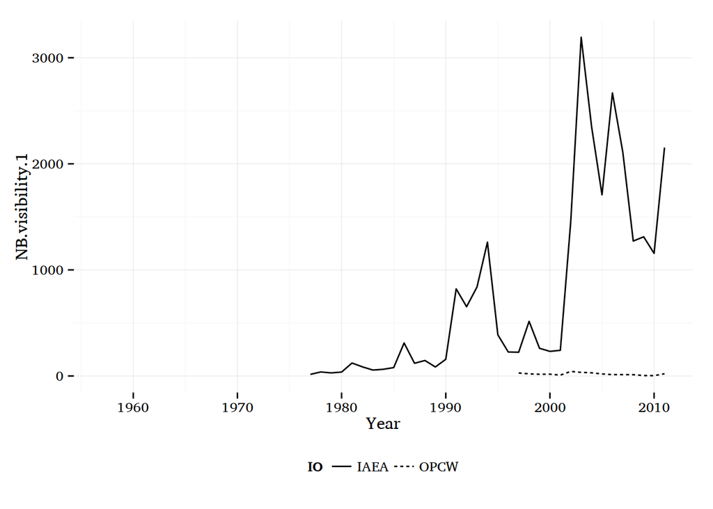

## NB-Press Headline

### IAEA

- Media salience in the headlines of articles
- Data as a share of headlines per total hits for comparability and to know when the organization is only cited and when there’s a focused article on the IO.
- Source: hits in the headlines of the “major world news” corpus of Lexis Nexis

```r
data$NB.visibility.2 <- rep(NA, 70)
data$NB.visibility.2[which(data$IO == "IAEA")] <-
    iaea_media$Headlines[1:55] /
    iaea_media$All.Hits[1:55]
```

### OPCW

```r
data$NB.visibility.2[which(data$IO == "OPCW")] <-
    opcw_media$Headlines[1:15] /
    opcw_media$AllHits[1:15]
```

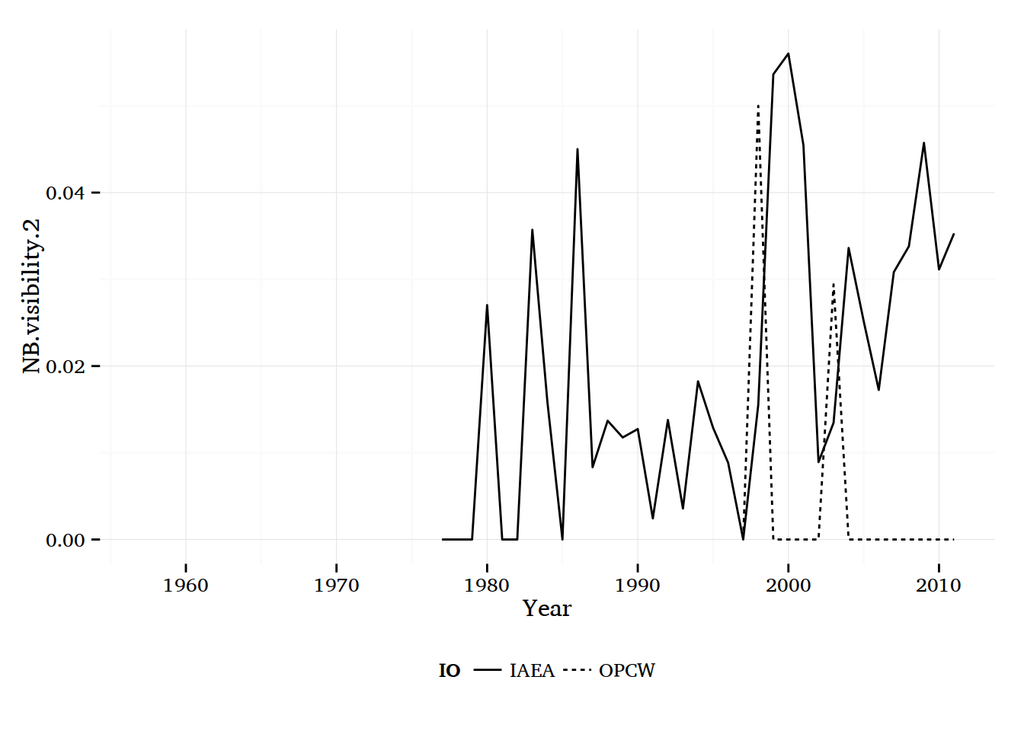

## NB-Democratic Members

### IAEA

- Provides the annual proportion of democratic members (Polity IV, `polity2` >= 7) of the whole organization.
- Source: Democracy values from POLITY IV dataset, membership data from organizations’ websites.

```r
# get Polity IV values with psData package, data available
polity4 <-
    PolityGet(url = "http://www.systemicpeace.org/inscr/p4v2012.sav",
    OutCountryID = "iso3c")
```

```
## 577 duplicated values were created when standardising the country ID with iso3c.
## 749 observations dropped based on missing values of the standardised ID variable.
```

```r
polity <- polity4[c(1,6,12)]

## merge with IAEA member data
iaea_polity <- merge(x = members_iaea, y = polity,
        by.x = c("isoc", "Year"), by.y = c("iso3c", "year"))

# dropped observations, due to missing data in polityIV
setdiff(unique(members_iaea$isoc), unique(iaea_polity$isoc))
```

```
##  [1] "VAT" "ISL" "MCO" "LIE" "ARE" "MHL" "MLT" "SYC" "BLZ" "PLW" "TON"
```

```r
# calculate share of states with polity2 >6 and other indicators
iaea_demmem <- iaea_polity %>% group_by(Year) %>%
    summarise(n = n(),
    mean_polity = mean(polity2, na.rm = T),
    n_democratic = sum(polity2 > 6, na.rm = T))
iaea_demmem$dem_share <- iaea_demmem$n_democratic / iaea_demmem$n


data$NB.dem.mem <- rep(NA, 70)
data$NB.dem.mem[which(data$IO == "IAEA")] <-
    iaea_demmem$dem_share
```

### OPCW

```r
## merge polity with OPCW member data
opcw_polity <- merge(x = members_opcw, y = polity,
        by.x = c("isoc", "Year"), by.y = c("iso3c", "year"))

# dropped observations, due to missing data in polityIV
setdiff(unique(members_iaea$isoc), unique(iaea_polity$isoc))
```

```
##  [1] "VAT" "ISL" "MCO" "LIE" "ARE" "MHL" "MLT" "SYC" "BLZ" "PLW" "TON"
```

```r
# calculate share of states with polity2 >6 and other indicators
opcw_demmem <- opcw_polity %>% group_by(Year) %>%
    summarise(n = n(),
    mean_polity = mean(polity2, na.rm = T),
    n_democratic = sum(polity2 > 6, na.rm = T))
opcw_demmem$dem_share <- opcw_demmem$n_democratic / opcw_demmem$n

data$NB.dem.mem[which(data$IO == "OPCW")] <-
    opcw_demmem$dem_share[1:15]
```

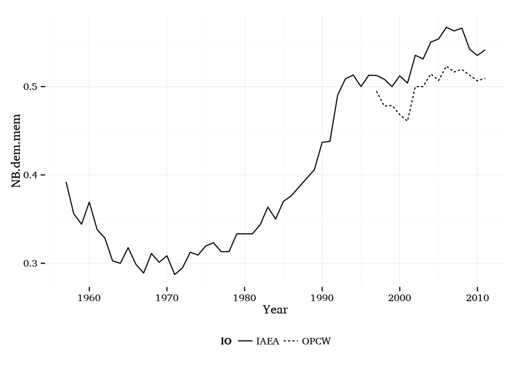

## NB-Governance Depth

### IAEA

- The authority of the IGO
- I will use the following qualitative factor levels to describe growing governance depth of the IAEA:
  - 1957 - 1969: business as usual
  - 1970 - 1990: NPT inspections
  - 1991 - 2011: contribution to political conflicts

```r
data$NB.gov.depth <- rep(NA, 70)
data$NB.gov.depth[which(data$IO == "IAEA")] <-
    c(rep(1, 13), rep(2, 21), rep(3, 21))
```

### OPCW

- The literature does not suggest any larger changes in the governance depth of the OPCW. The SYR inspections may be such an instance, but the event is outside of my time of analysis.

```r
data$NB.gov.depth[which(data$IO == "OPCW")] <-
    rep(1, 15)
```

## NB-Open Governance Norm

### IAEA

- The presence of the norm of open governance in the general public discourse, expressed as percentages of n-grams, multiplied by 10 Millions (to scale up to other variables).
- Source: google books n-grams (http://books.google.com/ngrams/), 1945-2008: keywords: `democratic deficit`, `participatory governance`, `global democracy`
- Sum of percentages into one single indicator of `open governance norm presence`.

```r
# get json data from n-grams site
url3 <-  "https://books.google.com/ngrams/graph?content=democratic+deficit%2Cparticipatory+governance%2Cglobal+democracy&case_insensitive=on&year_start=1957&year_end=2008&corpus=15&smoothing=0&share=&direct_url=t4%3B%2Cdemocratic%20deficit%3B%2Cc0%3B%2Cs0%3B%3Bdemocratic%20deficit%3B%2Cc0%3B%3BDemocratic%20Deficit%3B%2Cc0%3B%3BDemocratic%20deficit%3B%2Cc0%3B.t4%3B%2Cparticipatory%20governance%3B%2Cc0%3B%2Cs0%3B%3Bparticipatory%20governance%3B%2Cc0%3B%3BParticipatory%20Governance%3B%2Cc0%3B%3BParticipatory%20governance%3B%2Cc0%3B.t4%3B%2Cglobal%20democracy%3B%2Cc0%3B%2Cs0%3B%3Bglobal%20democracy%3B%2Cc0%3B%3BGlobal%20Democracy%3B%2Cc0%3B%3BGlobal%20democracy%3B%2Cc0%3B%3BGLOBAL%20DEMOCRACY%3B%2Cc0"

ngram <- htmlParse(getURL(url3))
ngram2 <- xpathSApply(ngram, "//script", xmlValue)[8]

# clean up and convert to data table
ngram2 <- gsub(pattern="\n  var data = ", x=ngram2,
                        replacement = "")
ngram2 <- gsub(pattern=
        ";\n  if (data.length > 0) {\n    ngrams.drawD3Chart(data, 1957, 2008, 1.0, \"main\");\n  }\n",
        x=ngram2, replacement = "", fixed=T)
write(ngram2, file='ngram2')

ngram3 <- fromJSON('ngram2')
dem_def <- unlist(ngram3[[1]], use.names = F)
part_gov <- unlist(ngram3[[2]], use.names = F)
global_dem <- unlist(ngram3[[3]], use.names = F)

# create data-frame and add years, first rows are junk,
# add missing values
open_gov_norm <- data.frame(democratic.deficit = dem_def,
        participative.governance = part_gov,
        global.democracy = global_dem)
open_gov_norm[56, ] <- c(NA, NA, NA)
open_gov_norm[57, ] <- c(NA, NA, NA)
open_gov_norm$year <- 1955:2011

# add values of all three search terms and
# add to data-set
open_gov_norm$ogn <-
    as.numeric(as.character(open_gov_norm$democratic.deficit)) +
    as.numeric(as.character(open_gov_norm$participative.governance)) +
    as.numeric(as.character(open_gov_norm$global.democracy))

# multiply with 10 Million and add to data table
data$NB.og.norm <- rep(NA, 70)
data$NB.og.norm[which(data$IO == "IAEA")] <-
    10000000 * open_gov_norm$ogn[3:57]
```

### OPCW

- The same data as for the OPCW.

```r
data$NB.og.norm[which(data$IO == "OPCW")] <-
    10000000 * open_gov_norm$ogn[43:57]
```

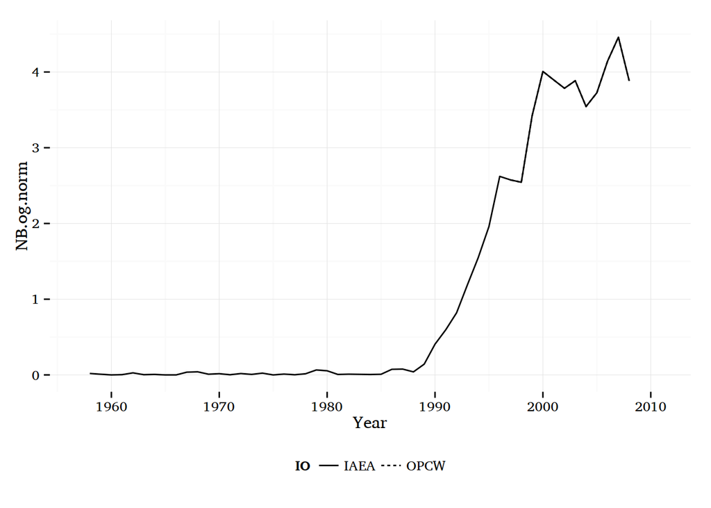

# Raw Data

[^1]: Vincent Arel-Bundock (2014). countrycode: Convert country names and country codes. R package version 0.17. http://CRAN.R-project.org/package=countrycode. David B. Dahl (2014). xtable: Export tables to LaTeX or HTML. R package version 1.7-4. http://CRAN.R-project.org/package=xtable. Daróczi, G. (2014). pander: An R Pandoc Writer. R package version 0.5.1, URL http://cran.r-project.org/package=pander Ingo Feinerer and Kurt Hornik (2014). tm: Text Mining Package. R package version 0.6. http://CRAN.R-project.org/package=tm. Christopher Gandrud (2014). psData: A package to download regularlymaintained political science data sets and make commonly used, but infrequently updated variables based on this data. R package version 0.1.2. http://CRAN.R-project.org/package=psData. Garrett Grolemund, Hadley Wickham (2011). Dates and Times Made Easy with lubridate. Journal of Statistical Software, 40(3), 1-25. http://www.jstatsoft.org/v40/i03/. Duncan Temple Lang (2013). XML: Tools for parsing and generating XML within R and S-Plus.. R package version 3.98-1.1. http://CRAN.R-project.org/package=XML. Duncan Temple Lang (2013). RCurl: General network (HTTP/FTP/…) client interface for R. R package version 1.95-4.1. http://CRAN.R-project.org/package=RCurl. Duncan Temple Lang (2014). RJSONIO: Serialize R objects to JSON, JavaScript Object Notation. R package version 1.3-0. http://CRAN.R-project.org/package=RJSONIO. Hadley Wickham (2007). Reshaping Data with the reshape Package. Journal of Statistical Software, 21(12), 1-20. URL http://www.jstatsoft.org/v21/i12/. H. Wickham. ggplot2: elegant graphics for data analysis. Springer :New York, 2009. Hadley Wickham and Romain Francois (2014). dplyr: A Grammar of Data Manipulation. R package version 0.3.0.2. http://CRAN.R-project.org/package=dplyr. Yihui Xie (2014). knitr: A general-purpose package for dynamic report generation in R. R package version 1.7. Achim Zeileis (2014). ineq: Measuring Inequality, Concentration, and Poverty. R package version 0.2-13. http://CRAN.R-project.org/package=ineq.